# Github, RStudio e Git

Fernando Bastos

15 de abril de 2018

## Rstudio, Github e Git

O controle de versão é essencial para quem está programando ou mesmo escrevendo um texto em latex ou em markdown. Assim vamos aprender a fazer isso no RStudio juntamente com o Git e o Github.

Já está com o RStudio instalado e uma conta no Github? Ótimo, mas você não está pronto ainda. Mãos a obra!

- Instale o Git (https://git-scm.com/downloads) no seu computador.

O Git é um sistema de código aberto, e o GitHub, um serviço de hospedagem de repositórios Git baseado na web.

- No Rstudio vá em Tools -> Global options -> select Git;

[figure not shown]

- Acrescente o endereço para o executável do Git, o endereço, geralmente, é:

<C:/Program Files (x86)/Git/bin/git.exe)>

- Em seguida crie uma chave RSA;

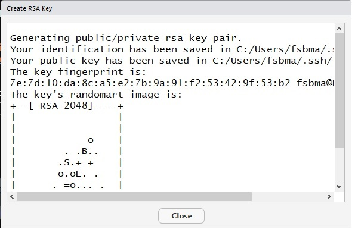

- Feche a janela e clique em View public key;

[figure not shown]

- Abra as configurações da sua conta no Github e clique na guia Chaves SSH. Clique em Adicionar chave SSH. Cole a chave pública que você copiou do RStudio.

[figure not shown]

1. Agora, abra o Git Bash e Digite o seguinte comando:

`ssh-keygen -t rsa -b 4096 -C "seu_email@dominio.com"`

Troque o e-mail!

O resultado será:

`Generating public/private rsa key pair.`  
`Enter file in which to save the key (/Users/you/.ssh/id_rsa): [Press enter]`

Você quer salvar a chave nesse arquivo mesmo, só dê enter. Ele então pede uma senha:

`Enter passphrase (empty for no passphrase): [Type a passphrase]`  
`Enter same passphrase again: [Type passphrase again]`

Pode deixar sem se preferir. Só dê enter. Ou coloque a senha e confirme.

Em seguida, você verá uma mensagem dizendo que deu tudo certo:

`Your identification has been saved in /Users/you/.ssh/id_rsa.`  
`# Your public key has been saved in /Users/you/.ssh/id_rsa.pub.` `#The key fingerprint is:` `# 01:0f:f4:3b:ca:85:d6:17:a1:7d:f0:68:9d:f0:a2:db seuemail@dominio.com`

2- Agora, vamos adicionar a chave que criamos ao ssh-agent. Primeiro, vamos ativa-lo:

`ssh-agent -s`

Em seguida, adicione a chave que geramos ao ssh-agent:

`ssh-add ~/.ssh/id_rsa`

3- Agora, vamos associar a chave que geramos à nossa conta do Github. Para copiar a chave do bash, digite o seguinte comando:

`clip < ~/.ssh/id_rsa.pub`

Isso tudo foi feito para configurar seu Git com a sua conta do Github. Vamos ver se funcionou?

Para testar a configuração digite o seguinte no Git Bash:

`ssh -T git@github.com`

O resultado deve ser:

`The authenticity of host 'github.com (207.97.227.239)' can't be established.`  
`# RSA key fingerprint is 16:27:ac:a5:76:28:2d:36:63:1b:56:4d:eb:df:a6:48.`

`# Are you sure you want to continue connecting (yes/no)?`

Digite `yes` e aperte enter.

`Hi username! You've successfully authenticated, but GitHub does not provide shell access.`

Se algo tiver dado errado, tente seguir todos os passos novamente.